# Ethica Data Preparation

Javad Khataei

02/07/2019

#### This file is an explanation for the data cleaning and extracting process. To extract the data, read the readme file and do not run this code.

## Summary

In this document, I explain the steps that I took to prepare the data for the SmartPhone Accel study. First, we need to understand the nature of the raw data and its issues. Second, We fix the problems and make the data ready for labeling. Third, we need to extract each participant data from these datasets and save them in separate CSV files. After this step, each person will have three different CSV files which have the accelerometer data for three different wear locations. Finally, we merge our data with the Jaeger data based on the record time.

## Ethica Accelerometer Data

Ethica exports the data based on the month; therefore, for each month, we download a separate zip file. Also, since we used three different devices to record the data, for each month, we have three different zip files. Each file has nine different columns.

#### columns’ names

“user_id”, “date”, “device_id”, “record_time”, “timestamp”, “accu”, “x_axis”, “y_axis”, and “z_axis”

### Wear Location

The first column of the data is user_id and use this column to identify the wear location of the device. Each participant used three smartphones to collect the data. The first one with an user_id of 2673 was held in the participant’s hand. The second phone, with an user_id of 2674 was in the participant’s backpack. The last device was in the participant’s pocket, and its user_id is 2675.

### Record Time

The second important column is the record_time column, which shows the reading time. One of the issues that we need to investigate more is the problem of record_time nonuniformity. For some seconds, we have 16 or 17 readings, and for some other seconds, we have 48 or 51 readings.  
To solve this issue, I decided to downsample the data and reduce its frequency to 10 measurements per second. I used this function to calculate the mean of the accelerometer readings for each tenth of a second to change the frequency.

#### The frequency convert function

```r
convert_freq <- function(df) {
  df <- df %>%  select(record_time, x_axis, y_axis, z_axis)

  # convert character to data
  df$record_time <- df$record_time %>% as_datetime()


  # floor the datetime to 0.1s intervals
  df <-
    df$record_time %>% floor_date(unit = "0.1s") %>% mutate(df, record_time = .)

  # calculate the mean of the readings inside the time period
  df_10hrz <-
    df %>% group_by(record_time) %>%  select(x_axis, y_axis, z_axis) %>%
    summarise(
      x_axis = mean(x_axis) ,
      y_axis = mean(y_axis),
      z_axis = mean(z_axis)
    )

  return(df_10hrz)
}
```

There are other columns such as date, device_id, timestamp and accu; however, we don’t need to use them for our analysis. Note that the “accu” column shows the accuracy of the readings and if its value is three, it means the measurement was accurate.

## Step one: Extract data for each participant

To use this code, we need to make sure that all the raw CSV files and the “intervals” file are inside the main_path folder. Here the main_path is set to “Z:/Research/dfuller/Walkabilly/studies/smarphone_accel/data/Ethica”.

```r
##-------------------------------------The root folder---------------------------------##
# set the working directory to the folder that has the raw data and the intervals file
OS <- Sys.info()
if (OS["sysname"] == "Windows") {
  main_path <-
    "Z:/Research/dfuller/Walkabilly/studies/smarphone_accel/data/Ethica"
} else {
  main_path <-
    "/Volumes/hkr-storage/Research/dfuller/Walkabilly/studies/smarphone_accel/data/Ethica"
}
setwd(dir = main_path)
```

### Looping the wear location and the date

We have a file named “intervals”, which has the start and the end time for each participant. We use this file to extract the data of each participant. We loop through, all months and wear locations in the code.

```r
mons <- c("01","02","03","04",'05')
dev_ids <- c("2673","2674","2675")
# #set the study year
study_year <- "2019"

for (dev_id in dev_ids) {
  for (mon in mons) {
    ## Do stuff
  }
}
```

### Get participants’ list

Then, based on the “intervals” file, we discover which participants are inside the selected month. These participants are stored in the variable “Selected_part”.

```r
#Select participants who participated during study_year_month
Selected_part <-
  intervals_file %>%  filter(intervals_file$year_month == study_year_month)
```

### Reading and slicing the data

In the next step, the Ethica raw data is read, and for each participant inside the “Selected_part” variable, we slice the raw data. To slice the raw data, we use the start and the end time of that particular participant read from the “intervals” file.

```r
    #find the start and the end of the participant's data
    record_time <<-
      df$record_time %>% as_datetime() %>%  floor_date(unit = "minute")
    start_time_index <<-
      which(record_time > participant_start_time) %>% first()
    end_time_index <<-
      which(record_time < participant_end_time) %>% last()

    #slice the participant's part
    df_slice <- df %>% slice(start_time_index:end_time_index)
```

### Adjust the time

Here, we encounter another issue; the times from the “intervals” file and the raw data do not match. To rectify this problem, we need to subtract 2 hours and 32, 38 or 36 minutes from the raw data.For the subjects participated before the Daylight saving time, which is 3:00 a.m. on Sunday, March 10, the difference is 3 hours and 32, 38 or 36 minutes. We do this adjustment inside the main loop. For each location, this time difference slightly varies so we need to adjust them like this:

```r
# adjust the raw data time using a temporary var
daylight_saving <- "2019-03-10"


# Participants after daylight saving
temp_df <- df
if (participant_start_time > daylight_saving) {
  if (dev_id == "2673") {
    temp_df$record_time <- temp_df$record_time - hms("2:32:00")
  } else if (dev_id == "2674") {
    temp_df$record_time <- temp_df$record_time - hms("2:38:00")
  } else if (dev_id == "2675") {
    temp_df$record_time <- temp_df$record_time - hms("2:36:00")
  }

} else
{
  # Before daylight saving
  if (dev_id == "2673") {
    temp_df$record_time <- temp_df$record_time - hms("3:32:00")
  } else if (dev_id == "2674") {
    temp_df$record_time <- temp_df$record_time - hms("3:38:00")
  } else if (dev_id == "2675") {
    temp_df$record_time <- temp_df$record_time - hms("3:36:00")
  }
}
```

### Mutate the location and participant’s id

After extracting the data, we add the wear location and the participant’s id to the dataset, and it is ready to be stored in a CSV file. We create a folder for each participant and save the datasets in it.

```r
    #add participant's id and waer location
    df_slice <-
      df_slice %>% mutate(participant_id = participant_id , wear_location = wear_loc)

    #create folders and save the data
    p_id <- as.character(participant_id)
    dir.create(p_id, showWarnings = FALSE)
    setwd(paste0(p_id, "/"))
    fwrite(x = df_slice , file = paste0(p_id, "_", wear_loc, ".csv"))
```

### The complete code

So after this step, for each participant, we have three CSV files which contain record time, accelerometer data for the X, Y and Z axis, participant id, wear location. The files are ready to get merged with Jaeger data and get labeled. If we put together all the above steps, the complete code is:

```r
#import libraries
library(data.table)
library(tidyverse)
library(lubridate)
library(scales)

##------------------------ Convert frequency function------------------------------##
convert_freq <- function(df) {
  df <- df %>%  select(record_time, x_axis, y_axis, z_axis)
  # convert character to data
  df$record_time <- df$record_time %>% as_datetime()

  #change frequency to 10 hz
  ## floor or round the datetime to 0.1s intervals
  df <-
    df$record_time %>% floor_date(unit = "0.1s") %>% mutate(df, record_time = .)

  df_10hrz <-
    df %>% group_by(record_time) %>%  select(x_axis, y_axis, z_axis) %>%
    summarise(
      x_axis = mean(x_axis) ,
      y_axis = mean(y_axis),
      z_axis = mean(z_axis)
    )

  return(df_10hrz)
}


##-------------------------------------The root folder---------------------------------##
# set the working directory to the folder that has the raw data and the intervals file
OS <- Sys.info()
if (OS["sysname"] == "Windows") {
  main_path <-
    "Z:/Research/dfuller/Walkabilly/studies/smarphone_accel/data/Ethica"
} else {
  main_path <-
    "/Volumes/hkr-storage/Research/dfuller/Walkabilly/studies/smarphone_accel/data/Ethica"
}
setwd(dir = main_path)



##------------------------- loop through all months and locations---------------------##
mons <- c("01","02","03","04",'05')

dev_ids <- c("2673","2674","2675")
# #set the study year
study_year <- "2019"


for (dev_id in dev_ids) {
  if (dev_id == "2673"){
    wear_loc <- "hand"
  }
  if (dev_id == "2674"){
    wear_loc <- "back"
  }
  if (dev_id == "2675"){
    wear_loc <- "pock"
  }


  for (mon in mons) {

    #create study's year and month
    study_year_month <- paste0(study_year, "_", mon)

    # create the file name to read the data
    file_name <-
      paste0(dev_id, "_", study_year, "_", mon, "_accelerometer.csv")


    #read the accelerameter file
    df <- fread(file = file_name)
    df$record_time <- df$record_time %>%  as_datetime()



    #change the frequency by calling convert_freq function
    df <- convert_freq(df)


    # read the interval files that has all the intrvals for different participants
    intervals_file <- fread(file = "intervals.csv")


    # get the year and the month out of intervals_file
    intervals_file <-
      as.Date(intervals_file$start) %>%  format(format = "%Y_%m") %>%  as.character() %>% mutate(intervals_file, year_month = .)

    #Select participants who participated during study_year_month
    Selected_part <-
      intervals_file %>%  filter(intervals_file$year_month == study_year_month)


    # for each selected participant
    Selected_part$userid %>% map(function(i) {

      #get the current participant and extract its info,i.e id, start and end time
      current_participant <-
        Selected_part %>%  filter(Selected_part$userid == i)

      participant_id <- current_participant$userid

      participant_start_time <-
        current_participant$start %>% as_datetime()

      participant_end_time <- current_participant$end %>% as_datetime()




      # adjust the raw data time using a temporary var
      daylight_saving <-"2019-03-10"


      # Participants after daylight saving
      temp_df <- df
      if (participant_start_time > daylight_saving) {

        if (dev_id == "2673"){
          temp_df$record_time <- temp_df$record_time - hms("2:32:00")
        } else if(dev_id == "2674"){
          temp_df$record_time <- temp_df$record_time - hms("2:38:00")
        } else if (dev_id == "2675"){
          temp_df$record_time <- temp_df$record_time - hms("2:36:00")
        }

      } else
      {
        # Before daylight saving
        if (dev_id == "2673"){
          temp_df$record_time <- temp_df$record_time - hms("3:32:00")
        } else if(dev_id == "2674"){
          temp_df$record_time <- temp_df$record_time - hms("3:38:00")
        } else if (dev_id == "2675"){
          temp_df$record_time <- temp_df$record_time - hms("3:36:00")
        }
      }

      #find the start and the end of the participant's data
      record_time <-
        temp_df$record_time %>% as_datetime() %>%  floor_date(unit = "minute")
      start_time_index <-
        which(record_time > participant_start_time) %>% first()
      end_time_index <-
        which(record_time < participant_end_time) %>% last()


      #slice the participant's part
      df_slice <- temp_df %>% slice(start_time_index:end_time_index)


      #add participant's id and waer location
      df_slice <-
        df_slice %>% mutate(participant_id = participant_id , wear_location = wear_loc)
      p_id <- as.character(participant_id)
      dir.create(p_id, showWarnings = FALSE)
      setwd(paste0(p_id, "/"))
      fwrite(x = df_slice , file = paste0(p_id, "_", wear_loc, ".csv"))
      setwd(dir = main_path)

    })
  }

}
```

## Step two : Impute and combine.

### Read participants’ list and their csv files inside a loop

```r
#read intervals file to get the participants ids
participant_list <- fread("intervals.csv")


# for participants 100 to 107 and 110, there is no Jaeger data. Also, Ethica data is not available in 2018
# so use participats 108, 109 , 111 to 159
participant_list <-
  participant_list %>%  na.omit() %>% slice((9:59)) %>% slice(-3) %>% select(userid)

# create a list of possible wear locations
wear_locations <- c("hand", "back", "pock")

# create a dataset to store all the final data
final_df <- NULL

# Read Ethica files, impute each one of them, and then bind them
participant_list$userid %>% map(function(participant_id) {
  wear_locations %>%  map(function(wear_loc) {
    # create Ethica file name a based on wear_loc and participant_id
    Ethica_file_name <<-
      paste0(participant_id, "/", participant_id, "_", wear_loc, ".csv")

    # read and convert to datetime
    working_df <- fread(Ethica_file_name)
    working_df$record_time <-
      working_df$record_time %>% as_datetime()
```

### Create an empty dataset with a frequency of 10 Hz

```r
    ## Create a dataframe with the same staring and end point as the data
    longer_df <-
      seq(
        first(working_df$record_time),
        last(working_df$record_time),
        by = period(num = 0.1, units = "second")
      ) %>%  as.data.frame()
    colnames(longer_df) <- "record_time"
```

### Join this empty dataset with data from the previous step

```r
    # Join the datasets
    working_df <-
      full_join(longer_df, working_df , by = "record_time")
```

### Impute the missing timesteps with linear interpolation

```r
    # impute NAs by linear intrapolation
    # na.interapolation  only works with numeric data
    working_df <- working_df %>%
      select(-wear_location) %>%
      na_interpolation()

    # add  wear location
    working_df$wear_location <- wear_loc
```

### merge the data with the previous participant

```r
    # bind all the data and store in final_df
    final_df <<- bind_rows(final_df, working_df)



    ##---------status---------------#
    print(paste0(Ethica_file_name," is added"))

  })

})
fwrite(x = final_df,file = "Ethica_imputed_combined.csv")
```

### The complete code is :

```r
#import libraries
library(data.table)
library(tidyverse)
library(lubridate)
library(scales)
library(activityCounts)
library(imputeTS)


##-------------------------------------The root folder---------------------------------##
# set the working directory to the folder that has the raw data and the intervals file
OS <- Sys.info()
if (OS["sysname"] == "Windows") {
  main_path <-
    "Z:/Research/dfuller/Walkabilly/studies/smarphone_accel/data/Ethica"
} else {
  main_path <-
    "/Volumes/hkr-storage/Research/dfuller/Walkabilly/studies/smarphone_accel/data/Ethica"
}
setwd(dir = main_path)


#read intervals file to get the participants ids
participant_list <- fread("intervals.csv")


# for participants 100 to 107 and 110, there is no Jaeger data. Also, Ethica data is not available in 2018
# so use participats 108, 109 , 111 to 159
participant_list <-
  participant_list %>%  na.omit() %>% slice((9:59)) %>% slice(-3) %>% select(userid)

# create a list of possible wear locations
wear_locations <- c("hand", "back", "pock")

# create a dataset to store all the final data
final_df <- NULL

# Read Ethica files, impute each one of them, and then bind them
participant_list$userid %>% map(function(participant_id) {
  wear_locations %>%  map(function(wear_loc) {
    # create Ethica file name a based on wear_loc and participant_id
    Ethica_file_name <<-
      paste0(participant_id, "/", participant_id, "_", wear_loc, ".csv")

    # read and convert to datetime
    working_df <- fread(Ethica_file_name)
    working_df$record_time <-
      working_df$record_time %>% as_datetime()

    ##---------status---------------#
    print(paste0(Ethica_file_name," is read"))

    ## Create a dataframe with the same staring and end point as the data
    longer_df <-
      seq(
        first(working_df$record_time),
        last(working_df$record_time),
        by = period(num = 0.1, units = "second")
      ) %>%  as.data.frame()
    colnames(longer_df) <- "record_time"

    # Join the datasets
    working_df <-
      full_join(longer_df, working_df , by = "record_time")


    # impute NAs by linear intrapolation
    # na.interapolation  only works with numeric data
    working_df <- working_df %>%
      select(-wear_location) %>%
      na_interpolation()

    # add  wear location
    working_df$wear_location <- wear_loc

    # bind all the data and store in final_df
    final_df <<- bind_rows(final_df, working_df)



    ##---------status---------------#
    print(paste0(Ethica_file_name," is added"))

  })

})
fwrite(x = final_df,file = "Ethica_imputed_combined.csv")
```

## Step three: Merge with Jaeger

After having each participant data in separate files, we can combine them with the Jaeger data.

### Place the files inside the proper folders

To join Ethica and Jaeger data, we need to place the CSV files produced in the previous section and the Jaeger files inside a root folder. As it is shown in the below picture, this root folder has two subfolders.  
The first subfolder should be named “Ethica”, and the second subfolder’s name should be “jaeger”. Inside the “Ethica” subfolder, place the “intervals.csv” file, so we can use it to get a list of the participants’ ids. Also, put the CSV files created in the previous section inside the “Ethica” folder. In the end, inside the “Ethica” folder, for each participant, we have a subfolder which has three CSV files. Each subfolder’s name should be the participant’s id. For example, for participant number 108, we have a folder called 108, which has three CSV files.  
For Jaeger data, we have a similar folder structure. Inside the “jaeger” folder, we have subfolders for each participant. Same as Ethica data, the folders’ names are participants ids. Inside those folders, labeled Jaeger files are placed.

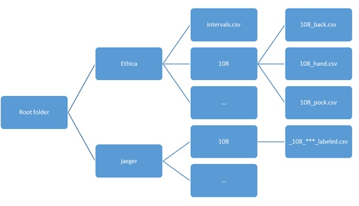

### Select the participants

For the participants 100 to 107 and 110, there is no Jaeger data, so we exclude them from the list.

```r
participant_list <-
  participant_list %>%  na.omit() %>% slice((9:59)) %>% slice(-3) %>% select(userid)
```

### Read the files

Next, we read all the Jaeger data and Ethica data for all the participants on the list. To do so, we need to create the proper name of the files.

```r
#repeat for each participant in the list
participant_list$userid %>% map(function(participant_id) {
  # create Jaeger file path and name based on participant id
  jaeger_file_path <- paste0("jaeger/", participant_id, "/")
  jaeger_file_name <-
    list.files(path = jaeger_file_path, pattern = "*_labeled.csv")
  jaeger_file_name <- paste0(jaeger_file_path, jaeger_file_name)


  #if we have the jaeger data then do the rest
  if (file.exists(jaeger_file_name)) {

    #read the jaeger data
    df_jaeger <- fread(jaeger_file_name[1])

    #repeat for each wear location
    wear_locations %>%  map(function(wear_loc) {
      # create Ethica file path and name based on wear_loc
      Ethica_file_path <- paste0("Ethica/", participant_id, "/")

      Ethica_file_name <-
        list.files(path = Ethica_file_path,
                   pattern =  paste0("*", wear_loc, ".csv"))

      Ethica_file_name <- paste0(Ethica_file_path, Ethica_file_name)

      #read Ethica data
      df_ethica <- fread(file = Ethica_file_name)
```

### Merge by time

Now, we can merge these datasets based on the record time column.

```r
      #prepare the column name and type
      colnames(df_jaeger)[colnames(df_jaeger) == "DateTime"] <-
        "record_time"
      df_ethica$record_time <- df_ethica$record_time %>% as_datetime()
      df_jaeger$record_time <- df_jaeger$record_time %>% as_datetime()

      #join the data, first step
      df_joined <-
        full_join(x = df_ethica, y = df_jaeger, by = "record_time")
```

### Impute missing values

The datasets are merged; however, the Jaeger frequency is 1, and the Ethica frequency is ten, so from every ten rows, only one of them has the Jaeger data. We need to impute the NA values in the Jaeger data, particularly the activity column; thus, every row is labeled based on its activity. We use the nearest neighbor method to assign an activity to each observation. The VIM package provides a KNN() function which we use to consider the closest neighbor, i.e., k is equal to one.

```r
# impute all NAs in activity column by KNN method from VIM package
      ## define a helper dataset to change the time to numeric and apply KNN (KNN doesn't work on date class)
      helper_df <-
        df_joined %>%  select(c(record_time, activity))
      helper_df$record_time <- helper_df$record_time %>%  as.numeric()

      # apply KNN
      helper_df <-
        kNN(data = helper_df , variable = "activity" , k = 1) %>% select(c(record_time, activity))

      # set the record time of the helper to datetime to join with the main dataset
      helper_df$record_time <- helper_df$record_time %>% as_datetime()
      df_joined <- inner_join(df_joined, helper_df , by = "record_time")


      #remove the extra activiy column and rename the main one
      df_joined <- df_joined %>% select(-activity.x)
      colnames(df_joined)[16] <- "activity"
```

### Export the data

In the end, the merged data for all participants is stored in a CSV file called “Ethica_jaeger_merged_total.csv”.

```r
      #output file name
      output_file_name <- paste0(participant_id,"_",wear_loc,"_jaeger_Ethica.csv")
      #store each participant merged data in a CSV file
      fwrite(x = df_joined,file = output_file_name)

      #add the data to the end of total dataset
      total_df <<- bind_rows(total_df, df_joined)
    })
  }
})
fwrite(x = total_df, file = "Ethica_jaeger_merged_total.csv")
```

### The complete code

Putting all the pieces together, we have a code which joins and labels the Ethica and the Jaeger data.  
To see the complete code, open merge_Ethica_Jaeger.R file.

## Step four: Add metadata

### Read the metadata from the “Smart_AccelStudy_Participant Register & O2 calculator - Register.csv” file

```r
metadata_path <- paste0(path, "Smart_AccelStudy_Participant Register & O2 calculator - Register.csv")

# read the metadata file starting from row 2 and the age, height and weight columns
metadata <- read.csv(metadata_path, header = T, skip = 2, check.names = F) [ ,c(2, 6, 7, 8, 10)]

# fix the metadata column names
metadata_col_names <- c("participant_id", "height", "weight", "age", "gender")
colnames(metadata) <- metadata_col_names
```

### Merge the data with the “Ethica_jaeger_merged.csv” file

```r
metadata <- metadata %>%
  mutate(participant_id = as.character(participant_id))
df <- df %>% mutate(participant_id = as.character(participant_id))

final_data_frame <- left_join(df, metadata, by = "participant_id")
```

### The Complete code can be found in the Add_Metadata.RMD file